```python
%reload_ext autoreload
%autoreload 2
%matplotlib inline
```

# Recorder and Annealing

> Parameter Scheduling

```python
#export

from exp.nb_04 import *

import torch.nn.functional as F
import torch.nn as nn
from functools import partial
```

## Get Data

```python
x_train, y_train, x_valid, y_valid = get_data()
train_ds, valid_ds = Dataset(x_train, y_train), Dataset(x_valid, y_valid)
nh = 50
bs = 512
c = y_train.max().item()+1
loss_func = F.cross_entropy
```

```python
data = DataBunch(*get_dls(train_ds, valid_ds, bs), c=c)
```

### Create Learner and Test

```python
#export
def create_learner(model_func, loss_func, data):
    return Learner(*model_func(data),loss_func, data)
```

```python
learn = create_learner(get_model, loss_func, data)
run = Runner(cbs=[AvgStatsCallback(accuracy)])
```

```python
run.fit(3, learn)
```

```
train: [0.667735703125, tensor(0.8055)]
valid: [0.33708525390625, tensor(0.8984)]
train: [0.30191533203125, tensor(0.9112)]
valid: [0.243979052734375, tensor(0.9282)]
train: [0.24016150390625, tensor(0.9305)]
valid: [0.202760400390625, tensor(0.9431)]
```

To change the learning rate we need to change the `get_model` default arg and pass it along to `create_learner` we do this with a partial:

```python
learn = create_learner(partial(get_model, lr=0.3), loss_func, data)
```

```python
run = Runner(cbs=[AvgStatsCallback(accuracy)])
run.fit(3, learn)
```

```
train: [0.77007109375, tensor(0.7936)]
valid: [0.369775732421875, tensor(0.8933)]
train: [0.346526640625, tensor(0.9011)]
valid: [0.2892301513671875, tensor(0.9174)]
train: [0.29322056640625, tensor(0.9165)]
valid: [0.251543115234375, tensor(0.9279)]
```

So we can wrap that partial in a function:

```python
#export
def get_model_func(lr=0.5): return partial(get_model, lr=lr)
```

## Recorder & Parameter Scheduling

Recent research has demonstrated the importance of varying certain parameters over the course of a training epoch.

Hyper-parameters like learning rate, momentum, and weight decay should be tuned and change according to the position in the training.

To do this we'll make two callbacks:

- `Recorder` which will track (or record) the loss and any other parameter we want
- `ParamScheduler` which will change any parameter that is registered in our optimizer param dict.

Let's start with the `Recorder`

```python
#export
class Callback():

    _order = 0

    def set_runner(self, run):
        self.run = run

    def __getattr__(self, k):
        return getattr(self.run, k)

    @property
    def name(self):
        name = re.sub(r'Callback$', '', self.__class__.__name__) # removes Callback from custom callback class name
        return camel2snake(name or "callback")
```

```python
#export
class Recorder(Callback):
    def begin_fit(self):
        self.losses = []
        self.lrs = []

    def after_step(self):
        if not self.in_train: return # don't
        self.losses.append(self.loss.detach().cpu())
        self.lrs.append(self.opt.param_groups[-1]['lr'])

    def plot_losses(self):
        plt.plot(self.losses)

    def plot_lr(self):
        plt.plot(self.lrs)
```

```python
learn = create_learner(get_model_func(), loss_func, data)
run = Runner(cb_funcs=[AvgStatsCallback(accuracy), Recorder()])
run.fit(3, learn)
```

```
train: [0.67179203125, tensor(0.8049)]
valid: [0.3221376953125, tensor(0.9067)]
train: [0.29242376953125, tensor(0.9155)]
valid: [0.2788956787109375, tensor(0.9176)]
train: [0.23997259765625, tensor(0.9303)]
valid: [0.2074302734375, tensor(0.9439)]
```

Alright our recorder is working. We can plot the losses:

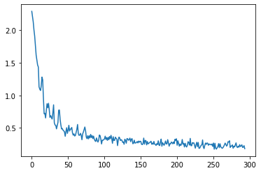

```python
run.recorder.plot_losses()
```

We can also plot the learning rate:

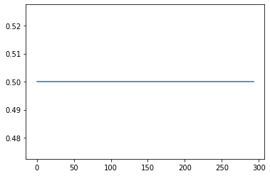

```python
run.recorder.plot_lr()
```

The learning rate here is constant for the entire duration of the epoch.

Let's fix that with a `ParamScheduler` callback:

```python
#export
class ParamScheduler(Callback):
    _order = 1

    def __init__(self, pname, sched_func):
        self.pname = pname
        self.sched_func = sched_func

    def set_param(self):
        for pg in self.opt.param_groups:
            pg[self.pname] = self.sched_func(self.n_epochs/self.epochs)

    def begin_batch(self):
        if self.in_train: self.set_param()
```

### Schedulers

Let's start easy with a linear scheduler.

We want a function that takes a place to start, an end, and the number of steps to take.

The start and end should be established before training starts and the function should then take in the current position and return the value.

We'll have to use `partial` for this.

```python
def linsched(start, stop):
    def _inner(start, stop, pos): return start + (stop - start) * pos
    return partial(_inner, start, stop)
```

```python
start = 0.1
end = 0.5
ls = linsched(start, end)
ls(.75)
```

```
0.4
```

A more pythonic and cleaner way of doing this would be to use a decorator:

```python
#export

def annealer(f):
    def _inner(start, end): return partial(f, start, end)
    return _inner

@annealer
def sched_lin(start, end, pos): return start + (end -start) * pos
```

```python
start = 0.1
end = 0.5
ls = sched_lin(start, end)
ls(.75)
```

```
0.4
```

Now we can use this decorator and define simple `sched` functions.

They take `start` and `end` args to initialize and then are called with a percentage of the epoch (between 0 - 1) and return a parameter value at that position.

The first and most obvious is `sched_no` which does nothing.

```python
#export

import math

@annealer
def sched_no(start, end, pos): return start

@annealer
def sched_cos(start, end, pos): return start + (1 + math.cos(math.pi*(1-pos))) * (end-start) / 2

@annealer
def sched_exp(start, end, pos): return start * (end/start) ** pos
```

```python
#export
def cos_1cycle_anneal(start, high, end):
    return [sched_cos(start, high), sched_cos(high, end)]
```

Plotting the different schedulers gives a clear picture of what they are doing over the course of an epoch.

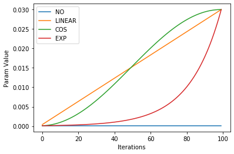

```python
annealings = "NO LINEAR COS EXP".split()

iterations = torch.arange(0,100)
pos = torch.linspace(0.01, 1, 100)

funcs = [sched_no, sched_lin, sched_cos, sched_exp]

for fn, title in zip(funcs, annealings):
    f = fn(1e-04, 3e-2)
    plt.plot(iterations, [f(o) for o in pos], label=title)

plt.xlabel("Iterations")
plt.ylabel("Param Value")
plt.legend()
```

The tricker part of scheduling is combining these functions together to design how our parameters are scheduled. We don't necessary want them to increase linearly, exponentially, or like a cosine.

```python
#export
def combine_scheds(pcts, scheds):
    assert sum(pcts) == 1.
    pcts = tensor([0] + listify(pcts))
    assert torch.all(pcts>=0)
    pcts = torch.cumsum(pcts, 0)
    def _inner(pos):
        idx = (pos >= pcts).nonzero().max()
        actual_pos = (pos-pcts[idx]) / (pcts[idx+1]-pcts[idx])
        return scheds[idx](actual_pos)
    return _inner
```

```python
sched = combine_scheds([0.4, 0.6], [sched_cos(0.3, 0.6), sched_cos(0.6, 0.2)])
```

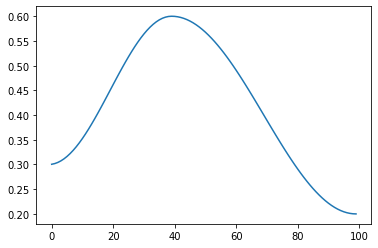

```python
pos = torch.linspace(0.01, 1, 100)
plt.plot(iterations, [sched(o) for o in pos])
```

## Testing

```python
scheduler = partial(ParamScheduler, 'lr', sched)
```

```python
learn = create_learner(get_model_func(0.3), loss_func, data)
run = Runner(cbs=[AvgStatsCallback(accuracy), scheduler()], cb_funcs=Recorder())
```

```python
run.fit(1, learn)
```

```
train: [0.732454609375, tensor(0.7949)]
valid: [0.30394931640625, tensor(0.9126)]
```

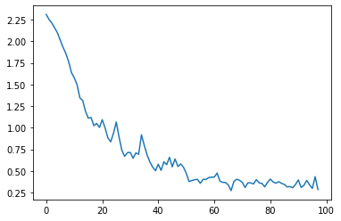

```python
run.recorder.plot_losses()
```

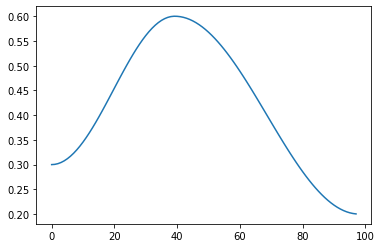

```python
run.recorder.plot_lr()
```

```python
!python notebook2script.py 05_recorder_annealing.ipynb
```

```
Converted 05_recorder_annealing.ipynb to exp\nb_05.py
```